# Time Series: A First Course with Bootstrap Starter

# Lesson 10-6: Computation of Optimal Predictors

- Calculating the predictors and the Gaussian likelihood is important.
- We explore algorithms for efficient computation.

## Remark 10.6.1. Computational Efficiency in R

- Speed: for time series longer than $n=1000$, direct inversion of covariance matrices becomes expensive, and it is important to use efficient algorithms.
- Memory: large data sets take up space (memory), so we only want to retain those portions that are needed.
- Recursive algorithms use less arithmetical operations (faster) and store fewer elements (less memory needed).

## Definition 10.6.4.

- The $k$-fold *predictors* are minimizers of the linear prediction MSE of $X_{k+1}$ from $\underline{X}_k = {[X_1, \ldots, X_k]}^{\prime}$. They are given by
  $$\underline{\varphi}_k = \Pi_k \, \Gamma_k^{-1} \, \underline{\gamma}_k,$$
  where $\Pi_k$ is a permutation matrix that reverses a vector (top to bottom).
- Recall $\underline{\gamma}_k = {[\gamma (1), \ldots, \gamma (k)]}^{\prime}$.
- So $\widehat{X}_{k+1} = \underline{\varphi}_k^{\prime} \underline{X}_k$.
- The last elements of the vector $\underline{\phi}_k$ weight the most recent data, and the first elements weight the old data.

## Proposition 10.6.9

- We can recursively compute $k$-fold predictors in terms of the PACF $\kappa (k+1)$ via
  $$\underline{\varphi}_{k+1} = \Pi_{k+1} \,
  \left[ \begin{array}{c} \Pi_k \, \underline{\varphi}_k -
  \underline{\varphi}_k \, \kappa (k+1) \\
  \kappa (k+1) \end{array} \right].$$

## Exercise 10.39. Recursive Predictors

- We write R code for the recursive computation of $k$-fold predictors.
- First we load the ARMAauto function.

```r
polymul <- function(a,b)
{
    bb <- c(b,rep(0,length(a)-1))
    B <- toeplitz(bb)
    B[lower.tri(B)] <- 0
    aa <- rev(c(a,rep(0,length(b)-1)))
    prod <- B %*% matrix(aa,length(aa),1)
    return(rev(prod[,1]))
}

ARMAauto <- function(phi,theta,maxlag)
{
    p <- length(phi)
    q <- length(theta)
    gamMA <- polymul(c(1,theta),rev(c(1,theta)))
    gamMA <- gamMA[(q+1):(2*q+1)]
    if (p > 0)
    {
        Amat <- matrix(0,nrow=(p+1),ncol=(2*p+1))
        for(i in 1:(p+1))
        {
            Amat[i,i:(i+p)] <- c(-1*rev(phi),1)
        }
        Amat <- cbind(Amat[,(p+1)],as.matrix(Amat[,(p+2):(2*p+1)]) +
            t(matrix(apply(t(matrix(Amat[,1:p],p+1,p)),2,rev),p,p+1)))
        Bmat <- matrix(0,nrow=(q+1),ncol=(p+q+1))
        for(i in 1:(q+1))
        {
            Bmat[i,i:(i+p)] <- c(-1*rev(phi),1)
        }
        Bmat <- t(matrix(apply(t(Bmat),2,rev),p+q+1,q+1))
        Bmat <- matrix(apply(Bmat,2,rev),q+1,p+q+1)
        Bmat <- Bmat[,1:(q+1)]
        Binv <- solve(Bmat)
        gamMix <- Binv %*% gamMA
        if (p <= q) { gamMix <- matrix(gamMix[1:(p+1),],p+1,1)
            } else gamMix <- matrix(c(gamMix,rep(0,(p-q))),p+1,1)
        gamARMA <- solve(Amat) %*% gamMix
    } else gamARMA <- gamMA[1]

    gamMA <- as.vector(gamMA)
    if (maxlag <= q) gamMA <- gamMA[1:(maxlag+1)] else gamMA <- c(gamMA,rep(0,(maxlag-q)))
    gamARMA <- as.vector(gamARMA)
    if (maxlag <= p) gamARMA <- gamARMA[1:(maxlag+1)] else {
    for(k in 1:(maxlag-p))
    {
        len <- length(gamARMA)
        acf <- gamMA[p+1+k]
        if (p > 0) acf <- acf + sum(phi*rev(gamARMA[(len-p+1):len]))
        gamARMA <- c(gamARMA,acf)
    } }
    return(gamARMA)
}
```

- Our function takes the ACF as input. We also incorporate the PACF calculation in the same loop.

```r
pred.k <- function(gamma,max.lag)
{
    kappa.vec <- gamma[2]/gamma[1]
    varphi.vec <- kappa.vec
    if(max.lag > 1) {
    for(k in 2:max.lag)
    {
        schur.new <- gamma[1] - t(varphi.vec) %*% rev(gamma[2:k])
        kappa.new <- (gamma[k+1] - sum(varphi.vec*gamma[2:k]))/schur.new
        kappa.new <- kappa.new[1,1]
        if(abs(kappa.new) < 10^(-15)) kappa.new <- 0
        kappa.vec <- c(kappa.vec,kappa.new)
        varphi.vec <- rev(varphi.vec) - kappa.new * varphi.vec
        varphi.vec <- rev(c(varphi.vec,kappa.new))
    } }
    return(varphi.vec)
}
```

- We illustrate on a cyclic AR(2) process.

```r
rho <- .8
omega <- pi/6
phi1 <- 2*rho*cos(omega)
phi2 <- -rho^2
gamma <- ARMAauto(c(phi1,phi2),NULL,20)
print(pred.k(gamma,20))
```

```
##  [1]  0.000000  0.000000  0.000000  0.000000  0.000000  0.000000  0.000000
##  [8]  0.000000  0.000000  0.000000  0.000000  0.000000  0.000000  0.000000
## [15]  0.000000  0.000000  0.000000  0.000000 -0.640000  1.385641
```

## Example 10.6.11. Predictors for Non-Defense Capitalization

- We compute the predictors for the MA(1) model fitted to the Non-Defense Capitalization data.
- As in Exercise 10.34, we have $\theta_1 = -.466$ and $\sigma^2 = .0053$.

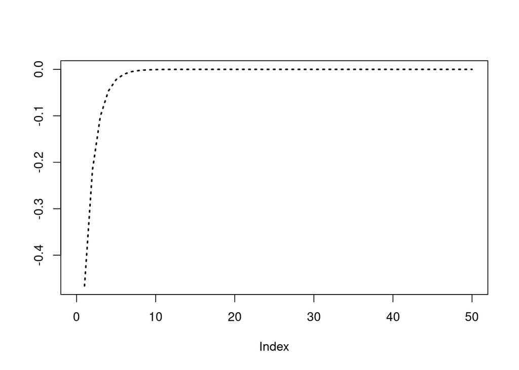

```r
theta <- -.466
sig.var <- .0053
max.lag <- 50
gamma <- rep(0,max.lag+1)
gamma[1] <- (1 +theta^2)*sig.var
gamma[2] <- theta*sig.var
varphi <- pred.k(gamma,max.lag)
plot(ts(c(NA,rev(varphi)),start=0),lty=3,lwd=2,xlab="Index",ylab="")
```